Lindsay: all of my peer comments will begin with “Lindsay” so that they’re easy to find! ## Every Saturday morning, at the same time, a primatologist goes and sits in the forest to listen for titi monkey calls, counting the number of calls they hear in a 2 hour window from 5am to 7am. Based on previous knowledge, she believes that the mean number of calls she will hear in that time is exactly 15. Let X represent the appropriate Poisson random variable of the number of calls heard in each monitoring session. ##Poisson distrubition is P(X=k)= ((e^-lambda*)(lambda^k))/k! ## lambda=15, which is mean. X= number of calls, k= number of occurences ## Set Lambda

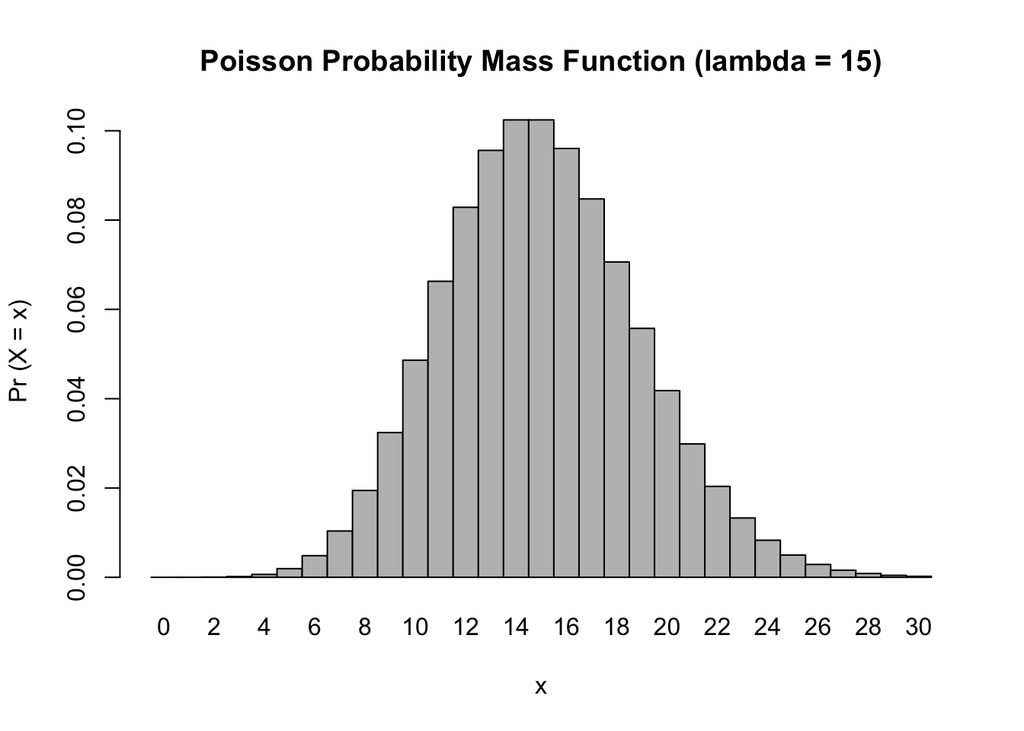

```r
lambda <- 15
# Probablity of more than 8 calls (x >8)
p_more_than_8 <- 1 - ppois(8, lambda= 15)
# No calls x=0
p_0_calls <- dpois(0, lambda = 15)
# Probablity of 3 calls
p_3_calls <- dpois(3, lambda = 15)
# Plot mass function Poisson over values 0-30. But first lets set x value range and establish that we are using Poisson distribution. After that we will plot our barplot function.
x <- 0:30
poisson_probs <- dpois(x, lambda = 15)
barplot(poisson_probs, names.arg = x, space = 0, xlab = "x", ylab = "Pr (X = x)", main = "Poisson Probability Mass Function (lambda = 15)")
```

```r
#Lindsay: I mean yeah this is more or less what I did for this section. I really liked your commentary on these topics in particular! Also, this reminded me to add titles to my own graph because I forgot to do that.
```

## Simulate 104 results (2 years of Saturday monitoring sessions)

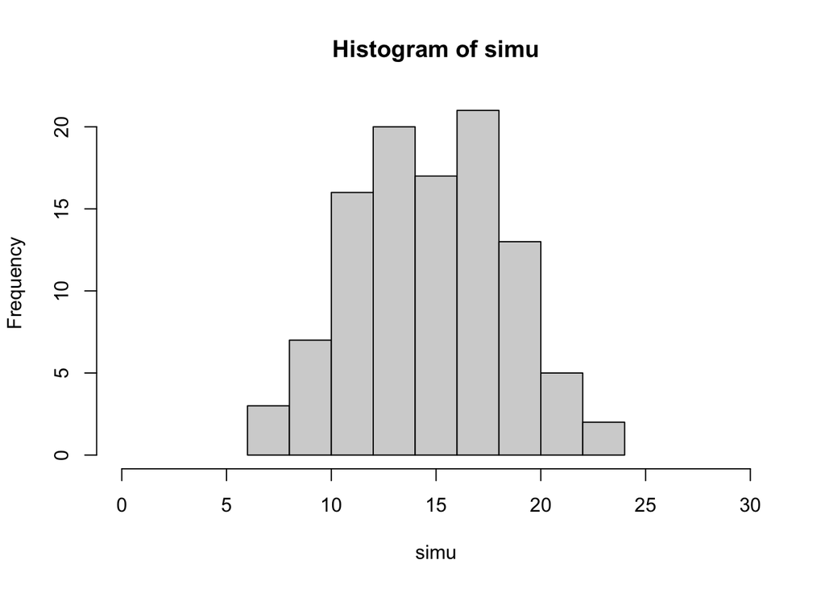

```r
set.seed (1) #sets up population
x <- 104
simu <- rpois (104, lambda = 15) #account for 104 random trials, using rpois command. putting this entire equation as a simulation ensures less syntax errors.
hist (simu, xlim = c(0,30)) #histogram accounts for all random trials, limits of x are also set.
```

```r
#Lindsay: This was also more or less what I did. I feel like the code was pretty straightforward overall. Again, good job commentating!
```

Lindsay: I think this was overall super well done and also similar to my code. The only main differences were that I didn’t set a lot of things equal to each other (for example, when the word lambda was set to 15). You could technically removed that if you wanted to but I don’t think it’s 100% necessary. I know for me personally it’s been a hot second since I’ve taken a Stats class so I forgot about the Poisson distribution and I struggled with figuring out what that was. But I think overall this was a straightforward homework and I think you did well with it!